## Dummy Variables

We will consider the case when we have a qualitative (categorical) predictor (also known as a factor) with two or more levels (or possible values).

**Qualitative predictors with only two levels**

To include a qualitative predictor in our model, we create a dummy variable that takes on two possible numerical values, e.g. 0 and 1.

Back to our used cars example, suppose we want to add the transmission type to our linear regression model. So let $d$ be a dummy variable represents the car’s transmission type which takes value 1 for manual car and value 0 for automatic car.

Again, $y=Price$ and $x_1=age$, and let us not include $x_2=miles$ at the moment.
$$d_i=\left\{\begin{array}{ll}
1& \text{if $i$th car is manual,}\\
0& \text{if $i$th car is automatic}\\
\end{array}\right.$$

then we can regress price on age and transmission type as

$$y=\beta_0+\beta_1 x_1+\beta_2
d+\epsilon$$

so for manual cars:
$$y=(\beta_0+\beta_2)+\beta_1 x_1+\epsilon$$
and for automatic cars:
$$y=\beta_0+\beta_1
x_1+\epsilon$$
or we can write

$$y_i=\beta_0+\beta_1 x_{1i}+ \beta_2
d_i+\epsilon_i =\left\{\begin{array}{ll}
(\beta_0+\beta_2) + \beta_1 x_{1i}+\epsilon_i& \text{if $i$th car is
manual,}\\
\beta_0+\beta_1 x_{1i}+\epsilon_i& \text{if $i$th car is
automatic}\\
\end{array}\right.$$

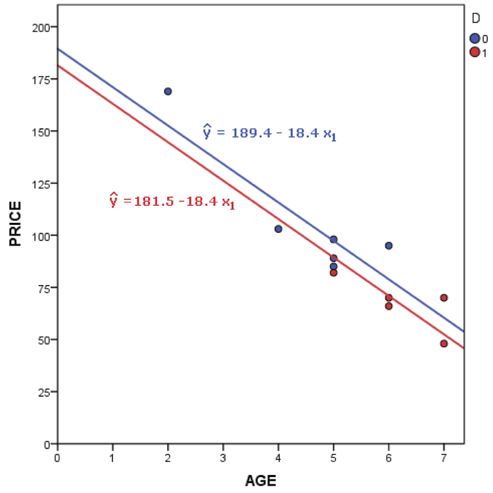

**Qualitative predictors with more than two levels**

Suppose we now have a categorical variable with three levels, e.g. fuel type (petrol, diesel, and hybrid). So in this case we need to create two dummy variables, $d_1$ and $d_2$.

$$d_{1i}=\left\{\begin{array}{ll}
1& \text{if $i$th car has a petrol engine,}\\
0& \text{otherwise}\\
\end{array}\right.$$

$$d_{2i}=\left\{\begin{array}{ll}
1& \text{if $i$th car has a diesel engine}\\
0& \text{otherwise}\\
\end{array}\right.$$

then one can regress price on age and fuel type as
$$y=\beta_0+\beta_1 x_{1}+\beta_2 d_{1}+\beta_3
d_{2}+\epsilon$$

so for petrol cars:
$$y=(\beta_0+\beta_2)+\beta_1
x_{1}+\epsilon$$

for diesel cars:
$$y=(\beta_0+\beta_3)+\beta_1 x_{1}
+\epsilon$$

and for hybrid cars
$$y=\beta_0+\beta_1
x_{1}+\epsilon$$
this last model is often called the baseline model.

$$\begin{align*}y_i&=\beta_0+\beta_1
\;x_{1i}+\beta_2 d_{1i}+\beta_3 d_{2i}+\epsilon_i\\
&=\left\{\begin{array}{ll}
(\beta_0+\beta_2)+\beta_1 x_{1i} +\epsilon_i& \text{if $i$th car has
a petrol engine,}\\
(\beta_0+\beta_3)+\beta_1 x_{1i} +\epsilon_i& \text{if $i$th
car has a diesel engine}\\
\beta_0+\beta_1 x_{1i}+\epsilon_i& \text{if $i$th car has a hybrid
engine}\\
\end{array}\right.
\end{align*}$$

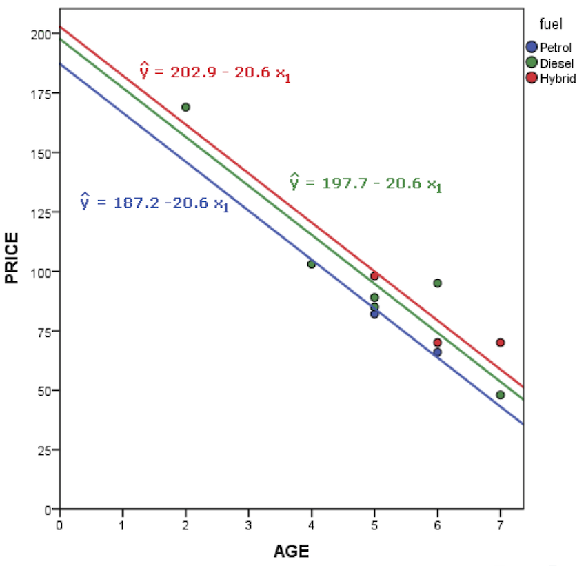

**The interaction effect**

In our used car example, we concluded that both age and miles seem to be associated with the price.
$$Y = \beta_0 +
\beta_1 x_1 + \beta_2 x_2 +\epsilon$$
$$Price = \beta_0 + \beta_1 age + \beta_2 miles
+\epsilon$$
that is the linear regression model assumed that the average effect on price of a one-unit increase in age is always $\beta_1$ regardless of the number of miles.

One can extend this model to allow for interaction effects, called an interaction term, which is constructed by computing the product of $x_1=age$ and $x_2=miles$, e.g. older cars associated with additional miles of driving.
$$Price =
\beta_0 + \beta_1 age + \beta_2 miles + \beta_3 (age\times
miles)+\epsilon$$
$$Price = \beta_0 +
(\beta_1+\beta_3\times miles) \times age + \beta_2 miles +
\epsilon$$
$$Price = \beta_0 +
\tilde{\beta}_1 \times age + \beta_2 miles + \epsilon$$

where $\tilde{\beta}_1 = \beta_1+\beta_3\times miles$. Since $\tilde{\beta}_1$ changes with $x_2=miles$, the effect of $x_1=age$ on $Y=Price$ is no longer constant.

That is adjusting $x_2=miles$ will change the impact of $x_1=age$ on $Y=Price$.

$~$